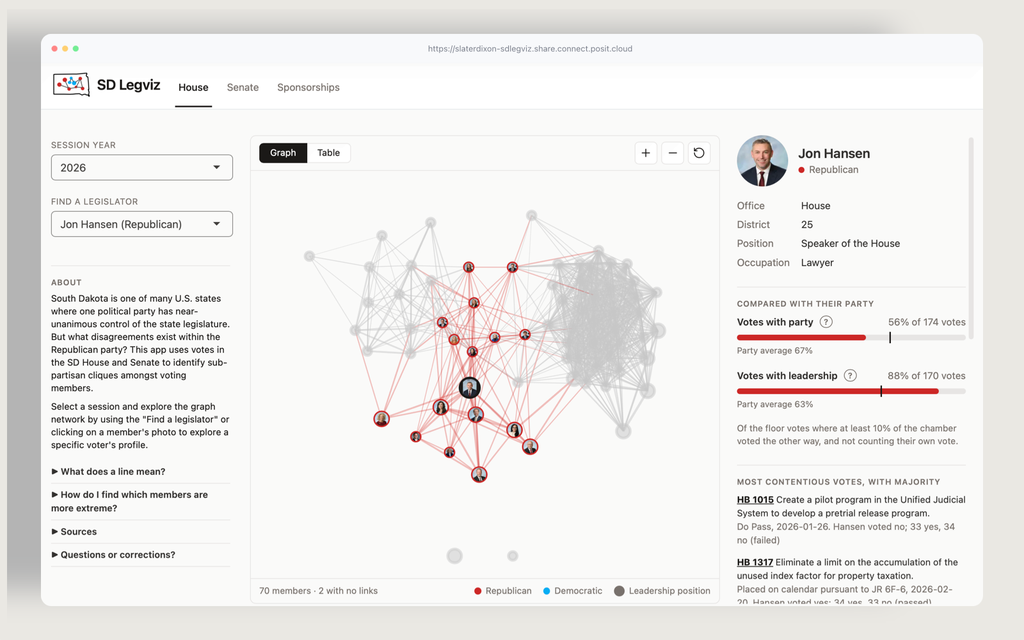

# `{sdlegviz}`

A dashboard for visualizing sub-partisan coalitions in the South Dakota legislature as unweighted graph networks, based on Zachary Neal’s Stochastic Degree Sequence Model.

## Structure

This package is divided into two sections:

### Data Pipeline

The data pipeline (`data-raw`) combines data for each legislative from Plural Policy’s Open States project (downloaded at `./pipeline-data/raw`) with metadata from the South Dakota Legislative Research Council to build legislators, bills, and roll call votes tables for each session. The output is parquet files `inst/extdata`, which includes projected unweighted backbones output by the `backbone` package and legislature info.

Legislator info from Openstates is inconsistent, so an authoritative list of legislators for each session are fetched from the LRC website and joined to Openstates identifiers using last names. The pipeline raises if it can not complete this join, requiring hand-keyed reconciliation via .csv files at `./pipeline-data/handkeyed`

`process_data.R` runs the full pipeline.

### Dashboard

The shiny dashboard presents the extracted backbones as interactive `visNetwork` graphs, with metadata. The dashboard is created using the golem framework, which packages the dashboard as an R package.

## Run

```r
golem::run_dev() # or source("dev/run_dev.R")
```

## Data

`source("data-raw/process_data.R")` rebuilds the app’s data in `inst/extdata` from the raw OpenStates data, set by `BASE_PATH` in `.env`.

## Deploy

See `dev/deploy.R`.